# (Prosper Loan Data)

## by (Mohamed Hekal)

## Investigation Overview

> In this investigation, I wanted to look at the factors that affect the loan status

## Dataset Overview

> This data about Prosper Marketplace, Inc. is a San Francisco, California-based company in the peer-to-peer lending industry. Prosper Funding LLC, one of its subsidiaries, operates Prosper.com, a website where individuals can either invest in personal loans or request to borrow money. The data contain 113937 raw and 81 columns.

## (Distribution of Loan Original Amount)

> Loan amount from the data set take a range from about the lowest 1k to the highest 35k. There are a much big spikes in different amount like 4k, 5K,10k and 15k. Almost few ask for fractions and a lot ask for multiples of five

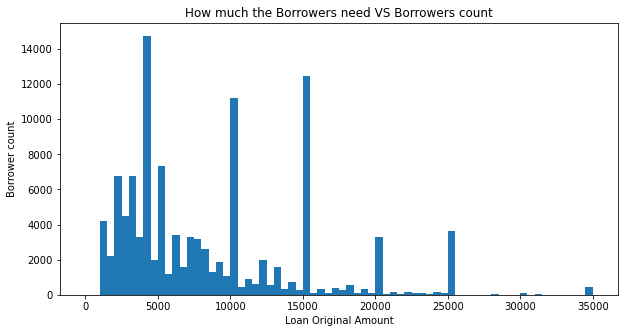

## (Distribution of Monthly Loan Payment)

> Monthly Loan Payment has a long-tailed distribution,a lot of borrowers pay little and few pay much.When plotted in logarithmic scale the distribution is a multimodal and have a big spike between 150 to 200 and one before 400

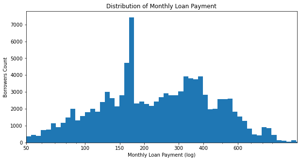

## (Term by Stated MonthlyIncome & MonthlyLoanPayment & LoanOriginalAmount)

It is not high interaction between term and monthly income, in normal higher in term lower in loan monthly payment but the plot shows that borrowers that loan for 5 years pay much every month and this because that these borrowers make a high Loan amount and it makes sense.

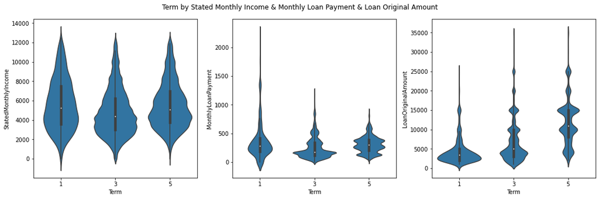

## (Loan Status By Term & Monthly Income & Monthly Loan Payment & Loan Original Amount )

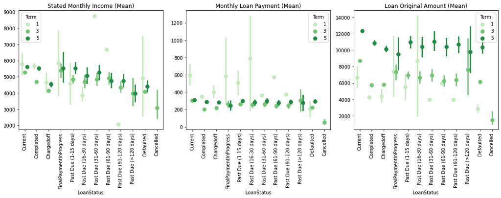